# crosnma to synthesize cross-design evidence and cross-format data using network meta-analysis

Tasnim Hamza and Georgia Salanti

2021-06-29

```r
library(crosnma)
library(rjags) # only for bias.method='adjust2' - to use the function load.module()
load.module('mix') # only for bias.method='adjust2' - to call the bimodal normal models to JAGS
```

# 1 Introduction

In network meta-analysis we synthesize all relevant available evidence about health outcomes from competing treatments. That evidence might come from different study designs and in different formats: from non-randomized studies (NRS) or randomized controlled trials (RCT) as individual participant data (IPD) or as aggregate data (AD). We set up the package `crosnma` to synthesize all available evidence.

This document demonstrates how to use `crosnma` to synthesize cross-design evidence and cross-format data via Bayesian network meta-analysis and meta-regression (NMA and NMR). All models are implemented in JAGS (Plummer 2003).

We describe the workflow within the package using a worked example from a network meta-analysis of studies for treatments in relapsing remitting multiple sclerosis (RRMS). The primary outcome is the occurrence of relapses in two years (binary outcome). In the analysis, the relative effect will be the odds ratio (OR). The aim is to compare the efficacy of four treatments using the data from 6 different studies in different formats and different designs.

# 2 The synthesis models

We first introduce the model that synthesizes studies with individual-level (IPD) or/and aggregate data (AD) ignoring their design (naïve synthesis). Then, we present three possible models that account for the different study designs. In the table below we set the notation that will be used in the description of the four models.

| Notation | Description | Argument in `crosnma.model()` |
| --- | --- | --- |
| $i=1, ..., np_j$ | participant id |  |
| $j=1, ..., ns$ | study id |  |
| $k=1, ..., K$ | treatment index |  |
| $ns_{IPD}, ns_{AD}, ns_{RCT}, ns_{NRS}$ | the number of studies. The index refers to the design or format of the study |  |
| $y_{ijk}$ | binary outcome (0/1) | `outcome` |
| $p_{ijk}$ | probability of the event to occur |  |
| $r_{jk}$ | the number of events per arm | `outcome` |
| $n_{jk}$ | the sample size per arm | `n` |
| $b$ | the study-specific reference | * |
| $u_{j}$ | The treatment effect of the study-specific reference |  |
| $\delta_{jk}$ | log(OR) of treatment k relative to $b$ |  |
| $x_{ijk}$ | the covariate | `covariate` |
| $\bar{x}_{j}$ | the mean covariate for study $j$ |  |
| $d_{Ak}$ | the basic parameters. Here, $d_{AA}=0$ when A set as the reference in the network | use `reference` to assign the reference treatment |
| $z_j$ | study characteristics to estimate the bias probability $\pi_j$ | `bias.covariate` |
| $w$ | common inflation factor of variance for the NRS estimates | the element `var.infl` in `run.nrs` |
| $\zeta$ | common mean shift of the NRS estimates | the element `mean.shift` in `run.nrs` |

*If the reference in the network ($A$) is available on the study, it is assigned automatically to that reference. If not, it is assigned to the first alphabetically ordered treatment on the study.

## 2.1 Naive synthesis

We synthesize the evidence from RCT and NRS without acknowledging the differences between them. We combine the IPD data from RCT and NRS in one model and we do the same in another model with the AD information. Then, we combine the estimates from both parts as described in Section 2.5.

**model IPD only**

$$y_{ijk} \sim Bernoulli(p_{ijk})$$
$$\begin{equation}
logit(p_{ijk}) =
\begin{cases}
u_j +\beta_{0,j} x_{ijk} & \text{if $k=b$}\\
u_j +\delta_{jk} + (\beta_{0,j}+\beta^w_{1,jk}) x_{ijk}+
(\beta^B_{1,jk}-\beta^w_{1,jk}) \bar{x}_{.j} & \text{if $k≠b$}
\end{cases}
\end{equation}$$

**model AD only**

$$r_{jk} \sim Binomial(p_{jk},n_{jk})$$
$$\begin{equation}
logit(p_{jk}) =
\begin{cases}
u_j & \text{if $k=b$}\\
u_j +\delta_{jk} +\beta^B_{1,jk} \bar{x}_{j} & \text{if $k≠b$}
\end{cases}
\end{equation}$$

## 2.2 Using non-randomized studies (NRS) as a prior

First we estimate the relative treatment effects using only the NRS (use `run.nrs` in `crosnma.model()` to control this process). Then we use the NRS estimates ($\hat{d}^{NRS}_{Ak},\hat{V}^{NRS}_{Ak}$) as a prior information for the basic parameters of RCT data, $d_{Ak} \sim N(\hat{d}^{NRS}_{Ak},\hat{V}^{NRS}_{Ak})$. To control the NRS influence in the RCT estimates, we can either inflate the prior variance by dividing it by a common inflation factor $w$ (the inflated variances are $\hat{V}^{NRS}_{Ak}/w$) or shift the NRS means by $\zeta$.

## 2.3 Bias-adjusted model 1

In this and the next model we incorporate the judgments about the study risk of bias (RoB) by extending the method introduced by Dias et al. (2010). In model 1 we add the bias term $\gamma_j R_j$ to both the AD and IPD parts of the model as follows:

**model IPD only**

$$\begin{equation}
logit(p_{ijk}) =
\begin{cases}
u_j +\beta_{0,j} x_{ijk} & \text{if $k=b$}\\
u_j +\delta_{jk} + (\beta_{0,j}+\beta^w_{1,jk}) x_{ijk}+
(\beta^B_{1,jk}-\beta^w_{1,jk}) \bar{x}_{.j}+\gamma_j R_j & \text{if $k≠b$}
\end{cases}
\end{equation}$$

**model AD only**

$$r_{jk} \sim Binomial(p_{jk},n_{jk})$$
$$\begin{equation}
logit(p_{jk}) =
\begin{cases}
u_j & \text{if $k=b$}\\
u_j +\delta_{jk} +
\beta^B_{1,jk} \bar{x}_{j}+\gamma_j R_j & \text{if $k≠b$}
\end{cases}
\end{equation}$$

where the bias indicator $R_j$ follows the following distribution

$$R_j \sim Bernoulli(\pi_j)$$

## 2.4 Bias-adjusted model 2

**model IPD only**

$$\begin{equation}
logit(p_{ijk}) =
\begin{cases}
u_j +\beta_{0,j} x_{ijk} & \text{if $k=b$}\\
u_j +\theta_{jk} + (\beta_{0,j}+\beta^w_{1,jk}) x_{ijk}+
(\beta^B_{1,jk}-\beta^w_{1,jk}) \bar{x}_{j} & \text{if $k≠b$}
\end{cases}
\end{equation}$$

**model AD only**

$$\begin{equation}
logit(p_{jk}) =
\begin{cases}
u_j & \text{if $k=b$}\\
u_j +\theta_{jk} +\beta^B_{1,jk} \bar{x}_{j} & \text{if $k≠b$}
\end{cases}
\end{equation}$$

where the bias-adjusted relative treatment effect ($\theta_{jk}$) are modelled as follows

$$\theta_{jk} \sim (1-\pi_j)N(d_{Ak}-d_{Ab}, \tau_\delta^2) + \pi_jN(d_{Ak}-d_{Ab}+\gamma_j, \tau_\delta^2+\tau_\gamma^2)$$

## 2.5 Assumptions about the model parameters

The table below summarizes the different assumptions implemented in the package about combining the parameters in the models described above.

| Parameter | Assumptions | Argument in `crosnma.model()` |
| --- | --- | --- |
| relative treatment effect ($\delta_{jk}$) | Random-effects: $\delta_{jk} \sim N(d_{Ak}-d_{Ab}, \tau_\delta^2)$ | `trt.effect='random'` |
|  | Common-effect: $\delta_{jk}=d_{Ak}-d_{Ab}$ | `trt.effect='common'` |
| Covariate effect $\beta_{0, j}$ | Independent effects: $\beta_{0, j} \sim N(0, 10^2)$ | `reg0.effect='independent'` |
|  | Random-effects: $\beta_{0,j} \sim N(B_0, \tau_{\beta_0})$ | `reg0.effect='random'` |
| Within-study covariate-treatment interaction ($\beta_{1, jk}^W$) | Random-effects: $\beta_{1, jk}^W \sim N(B_{1, Ak}^W-B_{1, Ab}^W, \tau_{\beta_1^W})$ | `regw.effect='random'` |
|  | Common-effect: $\beta_{1,jk}^W = B_{1, Ak}^W-B_{1, Ab}^W$ | `regw.effect='common'` |
| Between-study covariate-treatment interaction ($\beta_{1, jk}^B$) | Random-effects: $\beta_{1,jk}^B \sim N(B_{1, Ak}^B-B_{1, Ab}^B, \tau_{\beta_1^B})$ | `regb.effect='random'` |
|  | Common-effect: $\beta_{1,jk}^B = B_{1, Ak}^B-B_{1, Ab}^B$ | `regb.effect='common'` |
| Bias effect ($\gamma_{j}$) | Random-effects: $\gamma_{j} \sim N(\Gamma, \tau_{\gamma})$ | `bias.effect='random'` |
|  | Common-effect: $\gamma_{j} = \Gamma$ | `bias.effect='common'` |
| Bias probability ($\pi_j$) | $\pi_j \sim Beta(a,b)$ |  |
|  | $\pi_j = a+bz_j$ |  |

# 3 Synthesis of studies comparing drugs for relapsing-remitting multiple sclerosis

## 3.1 Description of the data

The data we use are fictitious but have been developed to resample to real RCTs with IPD and aggregate data included in Tramacere and Filippini (2015). The studies provide either aggregate data `std.data` (2 RCTs) or as individual participant data `prt.data` (3 RCTs and 1 cohort study). Both datasets compare in total four drugs which are anonymized.

The `prt.data` contains 2950 rows, each row refers to a participant in the study. We display the first few rows of the data set:

```r
head(prt.data)
```

```
#>   study outcome trt design age sex bias year
#> 1     1       0   D    rct  20   1  low 2002
#> 2     1       0   D    rct  29   0  low 2002
#> 3     1       0   D    rct  35   0  low 2002
#> 4     1       0   D    rct  38   0  low 2002
#> 5     1       0   D    rct  37   0  low 2002
#> 6     1       0   D    rct  32   0  low 2002
```

For each participant, we have information for the `outcome` relapse (0=no, 1=yes), the treatment label `trt`, the `age` (in years) and `sex` (0 = Female, 1 = Male) of the participant. The following columns are set on study-level (it is repeated for each participant in each study): the `study` id, the `design` of the study (needs to be either rct or nrs), the risk of `bias` on each study (can be set as low, high or unclear) and the `year` of publication .

The aggregate data has the standard format for meta-analysis

```r
head(std.data)
```

```
#>   study outcome   n trt design  age sex    bias year
#> 1     1      19  25   A    rct 34.3 0.2     low 2010
#> 2     1      11  25   C    rct 34.3 0.3     low 2010
#> 3     2      97 126   A    rct 30.0 0.4 unclear 2015
#> 4     2      89 125   C    rct 30.0 0.5 unclear 2015
```

## 3.2 Analysis

The network should be checked for its connectivity before running the analysis. This is a vital step as the model will run even if the network is not connected.

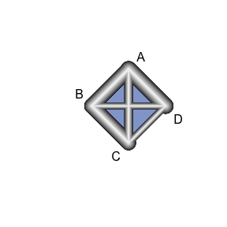

```r
netplot(prt.data,std.data)
```

In the following table, we summarize the number of studies from each design and each data format:

```r
knitr::kable(ns.tab(prt.data,std.data))
```

|  | IPD | AD |
| --- | --- | --- |
| RCT | 3 | 2 |
| NRS | 1 | 0 |

There are two steps to run the NMA/NMR model. The first step is to create a JAGS model using `crosnma.model()` which produces the JAGS code and the data. In the second step, the output of that function will be used in `crosnma.run()` to run the analysis through JAGS.

### 3.2.1 Naïve network meta-analysis

Optionally, we can specify a prior to the common heterogeneity of the treatment effect across studies through the `prior` argument we add `tau.trt='dunif(0,3)'`, see below.

```r
# jags model: code+data
 mod1 <- crosnma.model(prt.data=prt.data,
                   std.data=std.data,
                   trt=c('trt','trt'),
                   study=c('study','study'),
                   outcome=c('outcome','outcome'),
                   n='n',
                   design=c('design','design'),
                   trt.effect='random',
                   reference='A',
                   method.bias = 'naive',
                   #---------- assign a prior ----------
                   prior=list(tau.trt='dunif(0,3)')
                    )
```

Next, we fit the NMA model using `crosnma.run()`which requires us to set the number of adaptations, iterations, thinning and chains.

```r
# run jags
jagsfit1 <- crosnma.run(model=mod1,
                        n.adapt = 500,
                        n.iter=10000,
                        n.burnin = 4000,
                        thin=1,
                        n.chains=2)
```

We summarize the estimated parameters in the following table.

```r
knitr::kable(summary(jagsfit1,expo=F))
```

|  | Mean | SD | 2.5% | 50% | 97.5% | Rhat | n.eff |
| --- | --- | --- | --- | --- | --- | --- | --- |
| d.A | 0.000 | 0.000 | 0.000 | 0.000 | 0.000 | NaN | 0 |
| d.B | -0.198 | 0.711 | -1.638 | -0.192 | 1.202 | 1.001 | 11016 |
| d.C | 0.326 | 0.639 | -0.965 | 0.326 | 1.631 | 1.000 | 10724 |
| d.D | -0.889 | 0.779 | -2.465 | -0.892 | 0.721 | 1.000 | 13863 |
| tau | 1.063 | 0.449 | 0.481 | 0.959 | 2.278 | 1.000 | 3094 |

The estimated OR of B vs A can be obtained as exp(d.B) and similarly for exp(d.C) and exp(d.D) are the ORs of C and D relative to A, respectively. The value of tau refers to the estimates of the heterogeneity standard deviation in the relative treatment effects across studies.

We need also to assess the convergence of the MCMC chains either by visually inspect the trace plot or checking the Gelman and Rubin statistic, Rhat (it should be almost 1), see the above table.

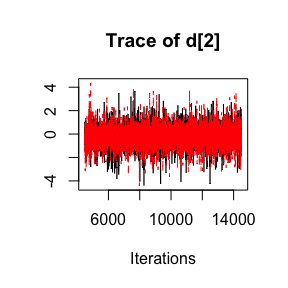

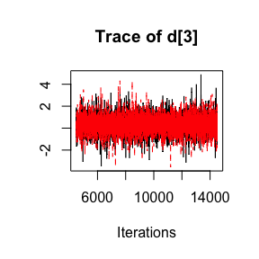

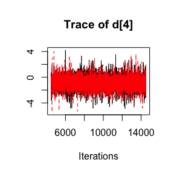

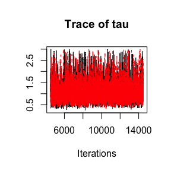

```r
coda::traceplot(jagsfit1$samples)
```

### 3.2.2 Naïve network meta-regression

In this part, we run NMR model by adding age as a covariate from both datasets. We set a list of elements `covariate=list(c('age'),c('age'))` representing the names of the covariate in `prt.data` and `std.data`, respectively.

```r
# jags model: code+data
mod2 <- crosnma.model(prt.data=prt.data,
                   std.data=std.data,
                   trt=c('trt','trt'),
                   study=c('study','study'),
                   outcome=c('outcome','outcome'),
                   n='n',
                   design=c('design','design'),
                   reference='A',
                   trt.effect='random',
                   #----------  meta-regression ----------
                   covariate = list(c('age'),c('age')),
                   split.regcoef = F,
                   #---------- bias adjustment ----------
                   method.bias='naive'
                   )
```

The MCMC is run under the same set up as in the network meta-analysis.

```r
# run jags
jagsfit2 <- crosnma.run(model=mod2,
                        n.adapt = 500,
                        n.iter=10000,
                        n.burnin = 4000,
                        thin=1,
                        n.chains=2)
```

and the output table is presented below

```r
knitr::kable(summary(jagsfit2))
```

|  | Mean | SD | 2.5% | 50% | 97.5% | Rhat | n.eff |
| --- | --- | --- | --- | --- | --- | --- | --- |
| b_1 | 1.011 | 1.096 | 0.874 | 1.013 | 1.157 | 1.062 | 5370 |
| d.A | 1.000 | 1.000 | 1.000 | 1.000 | 1.000 | NaN | 0 |
| d.B | 0.669 | 2.456 | 0.147 | 0.587 | 4.786 | 1.008 | 29 |
| d.C | 0.532 | 2.421 | 0.104 | 0.509 | 2.972 | 1.021 | 63 |
| d.D | 0.150 | 1.920 | 0.038 | 0.154 | 0.529 | 1.035 | 168 |
| tau | 0.508 | 0.356 | 0.040 | 0.435 | 1.452 | 1.019 | 325 |
| tau.b_1 | 0.076 | 0.139 | 0.002 | 0.032 | 0.511 | 1.047 | 166 |

Here, we additionally estimate b_1 which indicates the mean effect of age and tau.b_1 which refers to the heterogeneity standard deviation in the effect of age across studies. To improve the convergence of MCMC, we choose to not split the within- and between-study age coefficient therefore we obtain the estimate for a single parameter $(\beta^W_{1,jk} = \beta^B_{1,jk}=\beta_{1,jk})$.

Again, we check convergence with trace plots

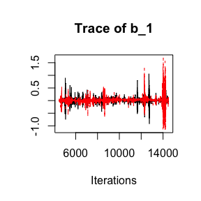

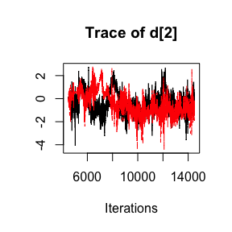

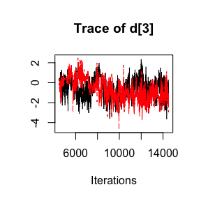

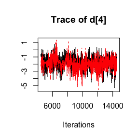

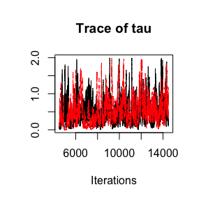

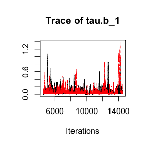

```r
coda::traceplot(jagsfit2$samples)
```

### 3.2.3 Using non-randomized studies as a prior in network meta-regression

To run NMA with a prior from NRS, two additional arguments are needed: we indicate using NRS as a prior by setting `method.bias='prior'`. That means that the model runs internally NMA with only NRS data which are then used to construct informative priors. This requires defining MCMC settings (the number of adaptations, iterations, burn-ins, thinning and chains) in the argument `run.nrs`.

In this method, the prior for the basic parameters is set to a normal distribution. For basic parameters not examined in the NRS, the code sets a minimally informative prior `d~dnorm(0, 1e-4)`. To account for possible bias, the means of the distribution can be shifted by `mean.shift` to reflect the potential bias in NRS and/or the variance can be inflated by `var.infl` to control the influence of NRS on the final estimation. Both should be provided in `run.nrs`.

```r
# jags model: code+data
mod3 <- crosnma.model(prt.data=prt.data,
                   std.data=std.data,
                   trt=c('trt','trt'),
                   study=c('study','study'),
                   outcome=c('outcome','outcome'),
                   n='n',
                   design=c('design','design'),
                   reference='A',
                   trt.effect='random',
                   #----------  meta-regression ----------
                   covariate = list(c('age'),c('age')),
                   split.regcoef = F,
                   #---------- bias adjustment ----------
                   method.bias='prior',
                   run.nrs=list(var.infl=0.6,
                                n.adapt = 500,
                                n.iter=10000,
                                n.burnin = 4000,
                                thin=1,
                                n.chains=2))
```

```
#> The data is analyzed assuming the studies has the same design
#>
```

```r
# run jags
jagsfit3 <- crosnma.run(model=mod3,
                        n.adapt = 500,
                        n.iter=10000,
                        n.burnin = 4000,
                        thin=1,
                        n.chains=2)
```

```r
knitr::kable(summary(jagsfit3))
```

|  | Mean | SD | 2.5% | 50% | 97.5% | Rhat | n.eff |
| --- | --- | --- | --- | --- | --- | --- | --- |
| b_1 | 1.012 | 1.082 | 0.880 | 1.016 | 1.149 | 1.015 | 1830 |
| d.A | 1.000 | 1.000 | 1.000 | 1.000 | 1.000 | NaN | 0 |
| d.B | 0.653 | 4.157 | 0.043 | 0.655 | 9.036 | 1.042 | 31 |
| d.C | 0.432 | 3.843 | 0.029 | 0.425 | 4.804 | 1.015 | 55 |
| d.D | 0.120 | 3.046 | 0.011 | 0.125 | 1.097 | 1.000 | 910 |
| tau | 0.855 | 0.505 | 0.050 | 0.790 | 1.888 | 1.001 | 822 |
| tau.b_1 | 0.075 | 0.112 | 0.003 | 0.039 | 0.448 | 1.023 | 160 |

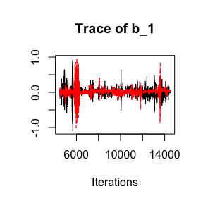

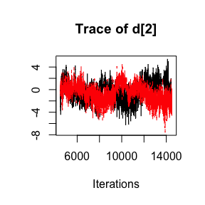

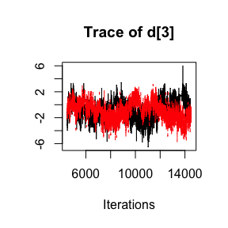

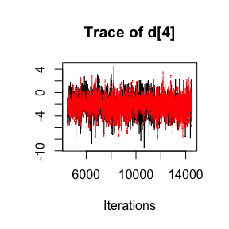

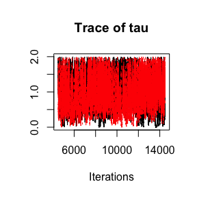

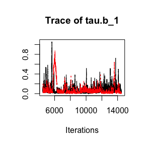

```r
coda::traceplot(jagsfit3$samples)
```

### 3.2.4 Bias-adjusted model 1

In this part, the overall relative treatment effects are estimated from both NRS and RCT with adjustment to study-specific bias.

To fit the model, we set `method.bias='adjust1'` and we need to provide the name of the bias variable `bias=c('bias','bias')` in `prt.data` and `std.data`, respectively. By default, the effect of bias is assumed to be additive `bias.type='add'` and equal across studies `bias.effect='common'`. We also use the `year` of study publication to estimate the study-probability of bias, `bias.covariate = c('year','year')`.

```r
# jags model: code+data
mod4 <- crosnma.model(prt.data=prt.data,
                   std.data=std.data,
                   trt=c('trt','trt'),
                   study=c('study','study'),
                   outcome=c('outcome','outcome'),
                   n='n',
                   design=c('design','design'),
                   reference='A',
                   trt.effect='random',
                   #---------- bias adjustment ----------
                   method.bias='adjust1',
                   bias=c('bias','bias'),
                   bias.type='add',
                   bias.effect='common',
                   bias.covariate = c('year','year')
                  )
```

```r
# run jags
jagsfit4 <- crosnma.run(model=mod4,
                       n.adapt = 500,
                        n.iter=10000,
                        n.burnin = 4000,
                        thin=1,
                        n.chains=2)
```

The results are presented below

```r
knitr::kable(summary(jagsfit4))
```

|  | Mean | SD | 2.5% | 50% | 97.5% | Rhat | n.eff |
| --- | --- | --- | --- | --- | --- | --- | --- |
| d.A | 1.000 | 1.000 | 1.000 | 1.000 | 1.000 | NaN | 0 |
| d.B | 0.817 | 1.952 | 0.206 | 0.819 | 3.173 | 1.001 | 11083 |
| d.C | 1.520 | 1.825 | 0.446 | 1.524 | 5.125 | 1.045 | 9200 |
| d.D | 0.424 | 2.069 | 0.098 | 0.422 | 1.909 | 1.004 | 13314 |
| g | 0.364 | 1058.324 | 0.000 | 0.134 | 6765717.630 | 1.313 | 6193 |
| tau | 1.012 | 0.354 | 0.492 | 0.948 | 1.842 | 1.001 | 4185 |

The parameter `g` refers to the mean bias effect, common for all studies.

The trace plots are shown below

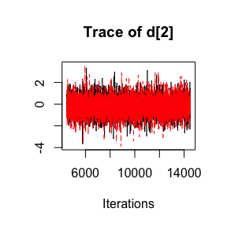

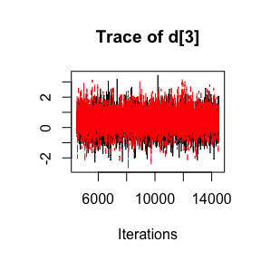

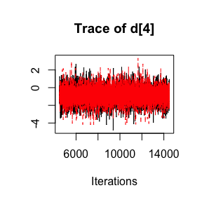

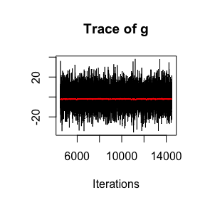

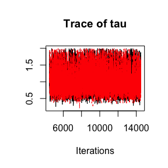

```r
coda::traceplot(jagsfit4$samples)
```

### 3.2.5 Bias-adjusted model 2

The arguments for `method.bias='adjust2'` are similar to the ones used before in `method.bias='adjust1'`.

```r
# jags model: code+data
mod5 <- crosnma.model(prt.data=prt.data,
                   std.data=std.data,
                   trt=c('trt','trt'),
                   study=c('study','study'),
                   outcome=c('outcome','outcome'),
                   n='n',
                   design=c('design','design'),
                   reference='A',
                   trt.effect='random',
                   #---------- bias adjustment ----------
                   method.bias='adjust2',
                   bias=c('bias','bias'),
                   bias.type='add',
                   bias.effect='common',
                   bias.covariate = c('year','year')
)
```

```r
# run jags
jagsfit5 <- crosnma.run(model=mod5,
                       n.adapt = 500,
                       n.iter=10000,
                       n.burnin = 4000,
                       thin=1,
                       n.chains=2)
```

```
#> NOTE: Stopping adaptation
```

```r
knitr::kable(summary(jagsfit5))
```

|  | Mean | SD | 2.5% | 50% | 97.5% | Rhat | n.eff |
| --- | --- | --- | --- | --- | --- | --- | --- |
| d.A | 1.000 | 1.000 | 1.000 | 1.000 | 1.000 | NaN | 0 |
| d.B | 1.056 | 2.893 | 0.127 | 1.039 | 9.703 | 1.000 | 310 |
| d.C | 2.216 | 5.145 | 0.078 | 2.070 | 74.445 | 1.001 | 153 |
| d.D | 0.691 | 6.358 | 0.015 | 0.641 | 43.738 | 1.000 | 149 |
| g | 0.620 | 4.013 | 0.031 | 0.641 | 11.950 | 1.004 | 148 |
| tau | 1.078 | 0.376 | 0.489 | 1.033 | 1.895 | 1.008 | 644 |

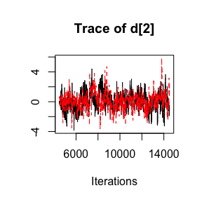

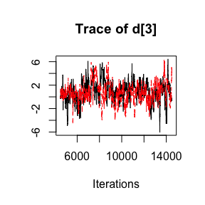

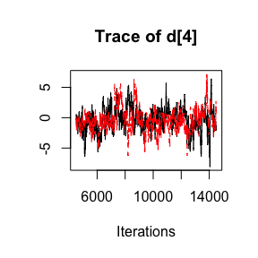

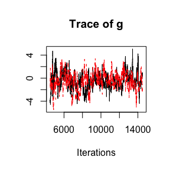

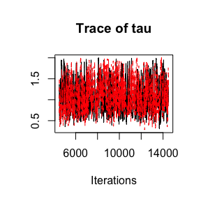

```r
coda::traceplot(jagsfit5$samples)
```

# References

Dias, Sofia, N. J. Welton, V. C. C. Marinho, G. Salanti, J.P.T Higgins, and A. E. Ades. 2010. “Estimation and Adjustment of Bias in Randomized Evidence by Using Mixed Treatment Comparison Meta-Analysis.” *Journal of the Royal Statistical Society* 173: 613–29.

Plummer, Martyn. 2003. “JAGS: A Program for Analysis of Bayesian Graphical Models Using Gibbs Sampling.”

Tramacere, Del Giovane, I, and G Filippini. 2015. “Immunomodulators and Immunosuppressants for Relapsing‐remitting Multiple Sclerosis: A Network Meta‐analysis.” *Cochrane Database of Systematic Reviews*, no. 9. John Wiley & Sons, Ltd. https://doi.org/10.1002/14651858.CD011381.pub2.

Verde, Pablo Emilio. 2020. “A Bias-Corrected Meta-Analysis Model for Combining, Studies of Different Types and Quality.” *Biometrical Journal. Biometrische Zeitschrift*, September. https://doi.org/10.1002/bimj.201900376.